## Homework 7

| Ivan Sanchez Fernandez |
| --- |
| Problem 1 |

Download the following data from https://www.dropbox.com/sh/p1ptxflh23i6pm8/AABJ-iWX4qq6n7-MEScMpBYda? dl=0&lst=: . PRAD_data_shuffled_noisy_PSET7.txt - Gene Expression data from patients with prostate cancer adenocarcinoma (TCGA dataset). Normalized RNAseq counts on 84 matched tumor-normal samples and 29,741 genes. Each row reports the expression levels of each gene across the samples. The data are already log2-transformed after adding an offset of 1. . PRAD_sample_info_PSET7.txt - Labels associated to the samples (“Primary Tumor” and “Solid Normal Tissue”). __ Note that sample names are not reported in the same order as the column names in the expression data file PRAD_data_shuffled_noisy_PSET7.txt. . RES_DESeq2_PRAD.txt - List of genes differentially expressed in Primary Tumors with respect to Solid Normal Tissue. Load the data in your workspace. Before training your classifier, it’s important to prepare your data. As a part of your data preparation, you might need to normalize your data so that it is consistent, as seen for the clustering. When you normalize, you actually adjust the range of all features (i.e. genes), so that distances between variables with larger ranges will not be over-emphasized. 1. Normalize the expression values for each gene by subtracting the minimum value for that gene and by dividing by the difference between the maximum and minimum value for that gene.

```r
#Load data and check that it looks more or less as expected
genedata <- read.table("F:\\BMI715 Computing Skills for Biomedical Sciences\\Homework7\\PRAD_data_shuffled_noisy_PSET7.txt", header = TRUE, sep = "\t")
genedata[1:10, 1:5]
```

```
##          TCGA_HC_8259_11A TCGA_EJ_7123_11A TCGA_EJ_7781_01A
## TSPAN6          15.107235        13.557805        14.878536
## TNMD             5.007813         8.404886         3.798995
## DPM1            12.714562        18.266567        13.995106
## SCYL3           13.952080        10.277330        13.010220
## C1orf112        10.675690        12.124912        11.324041
## FGR             10.321042        13.260345        11.524785
## CFH              9.927883        11.580702        12.041692
## FUCA2           19.773542        18.871599        13.129350
## GCLC            11.737377        20.140534        12.366929
## NFYA            14.464986        17.072102        13.393431
##          TCGA_EJ_7314_01A TCGA_EJ_7797_11A
## TSPAN6          15.263924        15.938492
## TNMD             5.398214         7.032373
## DPM1            11.558530        16.813895
## SCYL3           11.540668        18.247356
## C1orf112        11.008488        14.378647
## FGR              8.525269        10.434398
## CFH             11.729503        10.939329
## FUCA2           13.751901        16.295183
## GCLC            13.135424        13.322531
## NFYA            13.679132        11.863319
```

```r
genesample <- read.table("F:\\BMI715 Computing Skills for Biomedical Sciences\\Homework7\\PRAD_sample_info_PSET7.txt", header = TRUE, sep = "\t")
genesample[1:10, 1:2]
```

```
##         Sample_Name           Condition
## 1  TCGA_G9_6365_11A Solid Tissue Normal
## 2  TCGA_CH_5769_11A Solid Tissue Normal
## 3  TCGA_HC_8259_01A       Primary Tumor
## 4  TCGA_EJ_7315_01A       Primary Tumor
## 5  TCGA_CH_5768_01A       Primary Tumor
## 6  TCGA_EJ_7785_01A       Primary Tumor
## 7  TCGA_EJ_7794_11A Solid Tissue Normal
## 8  TCGA_CH_5768_11A Solid Tissue Normal
## 9  TCGA_EJ_7317_01A       Primary Tumor
## 10 TCGA_HC_7742_11A Solid Tissue Normal
```

```r
genediff <- read.table("F:\\BMI715 Computing Skills for Biomedical Sciences\\Homework7\\RES_DESeq2_PRAD.txt", header = TRUE, sep = "\t")
genediff[1:10, 1:5]
```

```
##            baseMean log2FoldChange      lfcSE        stat       pvalue
## TSPAN6   4566.80873   -0.005656142 0.09671310 -0.05848372 9.533633e-01
## TNMD       26.29104   -1.374897819 0.32652756 -4.21066394 2.546213e-05
## DPM1     1586.60727   -0.187201681 0.06278721 -2.98152594 2.868157e-03
## SCYL3    1332.80629    0.164029587 0.07327866  2.23843582 2.519265e-02
## C1orf112  252.42867   -0.023198092 0.07798493 -0.29746891 7.661085e-01
## FGR       324.97614   -0.307400293 0.14424650 -2.13107628 3.308286e-02
## CFH      2025.06551   -1.065083117 0.18423406 -5.78114130 7.419554e-09
## FUCA2    3674.63067    0.556293570 0.08560514  6.49836618 8.119698e-11
## GCLC     3652.73876   -0.262641067 0.08930875 -2.94082121 3.273434e-03
## NFYA     2113.81499    0.242489570 0.07070881  3.42941112 6.048925e-04
```

```r
#Normalize the expression values and check that the dataframe looks reasonable
#Explanation of the single line equation below: for each element in the column (in the transposed matrix the genes are in the columns), I subtract the minimun and divide that by the difference between the maximum and the minimum
normalizedgenedata <- t(apply(t(genedata), 2, function(x) (x - min(x, na.rm = TRUE)) / (max(x, na.rm = TRUE) - min(x, na.rm = TRUE))))
normalizedgenedata[1:10, 1:5]
```

```
##          TCGA_HC_8259_11A TCGA_EJ_7123_11A TCGA_EJ_7781_01A
## TSPAN6          0.3156133        0.1388313        0.2895200
## TNMD            0.2929285        0.5900135        0.1872134
## DPM1            0.2532763        0.9546923        0.4150545
## SCYL3           0.4234495        0.0000000        0.3149169
## C1orf112        0.3200068        0.4726045        0.3882757
## FGR             0.3325920        0.6314207        0.4549724
## CFH             0.1135452        0.2504417        0.2886237
## FUCA2           0.9805432        0.8764571        0.2137893
## GCLC            0.0389582        1.0000000        0.1109580
## NFYA            0.4204588        0.7197807        0.2974340
##          TCGA_EJ_7314_01A TCGA_EJ_7797_11A
## TSPAN6          0.3334907        0.4104555
## TNMD            0.3270703        0.4699828
## DPM1            0.1072282        0.7711681
## SCYL3           0.1455771        0.9184035
## C1orf112        0.3550492        0.7099144
## FGR             0.1500221        0.3441166
## CFH             0.2627663        0.1973193
## FUCA2           0.2856330        0.5791332
## GCLC            0.1988483        0.2202471
## NFYA            0.3302352        0.1217625
```

Then, in order to assess your model’s performance later, you will need to divide the data set into two parts: a training set and a test set. The first is used to train the classifiers, while the second is used to evaluate the classifier. In practice, the division of your data set into a test and a training sets is disjoint: the most common splitting choice is to take 2/3 of your original data set as the training set, while the 1/3 that remains will compose the test set. In addition, you need to make sure that the two classes of samples are present in the training model and the number of samples belonging to the two classes is balanced in order to not favour one or the other class in your predictions. 2. Write a function named TRind that splits the input data into training and test sets across samples, considering the number of samples for the test set provided as input. If possible, the training and test sets should have an equal number of samples from each class (i.e. Primary Tumor and Solid Tissue Normal). In defining the training and test set, use the function sample to randomly pick the samples from each class, in order to have different partitions if you run the function multiple times. The TRind function should have 2 input arguments: . A vector y indicating the labels of the two classes of samples (note that the labels provided as input have to be ordered according to the column names of the data in the data matrix that you will use for classification) . The percentage p of samples that will be used for the training set. Use the round function to convert the given percentage of samples into an integer. . An integer seed with a default value of 0 to initialize the random number generator before it is used in the function, e.g. in sampling indices. As output, the function provides a vector of indices into the input vector y that will make up the training set. In order to better understand the type of output to provide, use as reference the function createDataPartition from package caret but do not use createDataPartition as part of your TRind function. Note that in order to receive full credit, the function must be generic so that it can be applied also to labels different from our data. Assume that the labels are provided for a binary classification, that means you can assume exactly two classes.

```r
#Create function TRind
TRind <- function(y, p, seednumber = 0) {

  #INPUTS:
  # y (vector): indicating the labels of the two classes
  # p (numeric): proportion of samples used in the training set
  # seed (integer): initialize random number generator (default is 0)

  #OUTPUT:
  # classifiertraintest (vector): indicating the clusters of the two classes

  ## FUNCTION

  ## Round the proportion
  p = round(p, digits = 2)

  ## Transform the vector into a dataframe so that each row has an index
  ydf <- data.frame(y)
  ydf$index <- as.numeric(as.character(rownames(ydf)))

  ## As the database has 2 categories, and we want to ensure that the categories are similarly distributed in training and testing sets, we sample separately each category

  ## For category 1

  # Identify the indexes associated with category 1
  indexescategory1 <- ydf[ydf$y == levels(ydf$y)[1], ][ , "index"]

  # Set the seed to the seed specified above for reproducibility
  set.seed(seednumber)

  # Sample only from the first category and assign the elements belonging to the train set
  assignedtotraincategory1 <- sample(indexescategory1, p * length(indexescategory1), replace = FALSE)


  ## For category 2

  # Identify the indexes associated with category 2
  indexescategory2 <- ydf[ydf$y == levels(ydf$y)[2], ][ , "index"]

  # Set the seed to the seed specified above for reproducibility
  set.seed(seednumber)

  # Sample only the second category and assign the elements belonging to the training set
  assignedtotraincategory2 <- sample(indexescategory2, p * length(indexescategory2), replace = FALSE)


  # Create the output vector comprising the indexes of the training set
  classifiertrain <- sort(c(assignedtotraincategory1, assignedtotraincategory2))

  # Output
  classifiertrain
}


## Make sure that the function TRind outputs something similar to the expected
# Order the dataframe of samples following the order of the columns of samples in the genedata dataframe
orderedgenesample <- data.frame()
for (i in 1 : dim(genesample)[1]) {

  # Identify the rownumber in the gene samples dataframe with the same sample as the ith column of the gene data dataframe
  rownumber = which(grepl(colnames(genedata)[i], genesample[ , 1]))

  # Add that row to the ordered gene sample dataframe
  orderedgenesample <- rbind(orderedgenesample, genesample[rownumber, ])
}

# Evaluate if the order of the samples in the colnames of the gene data is the same as the order of the ordered gene sample dataframe
colnames(genedata)[1:10]
```

```
##  [1] "TCGA_HC_8259_11A" "TCGA_EJ_7123_11A" "TCGA_EJ_7781_01A"
##  [4] "TCGA_EJ_7314_01A" "TCGA_EJ_7797_11A" "TCGA_EJ_7331_01A"
##  [7] "TCGA_G9_6348_01A" "TCGA_G9_6351_11A" "TCGA_G9_6351_01A"
## [10] "TCGA_HC_7742_01A"
```

```r
orderedgenesample[1:10, 1]
```

```
##  [1] TCGA_HC_8259_11A TCGA_EJ_7123_11A TCGA_EJ_7781_01A TCGA_EJ_7314_01A
##  [5] TCGA_EJ_7797_11A TCGA_EJ_7331_01A TCGA_G9_6348_01A TCGA_G9_6351_11A
##  [9] TCGA_G9_6351_01A TCGA_HC_7742_01A
## 84 Levels: TCGA_CH_5761_01A TCGA_CH_5761_11A ... TCGA_J4_A83J_11A
```

```r
# Create the vector of samples
orderedvectorofsamples <- orderedgenesample[ , 2]

# Evaluate whether TRind outputs the expected output under different seeds
TRind(orderedvectorofsamples, 2/3)
```

```
##  [1]  1  2  3  4  5  6  9 10 11 12 13 14 15 16 17 19 20 22 25 26 29 31 34
## [24] 35 37 39 40 42 43 44 46 48 49 51 52 54 55 57 58 59 60 62 64 65 67 68
## [47] 70 71 73 74 75 76 78 79 80 83
```

```r
TRind(orderedvectorofsamples, 2/3, 256)
```

```
##  [1]  1  2  3  4  7  8 10 12 13 15 17 19 20 21 22 23 25 26 27 28 29 31 32
## [24] 33 34 35 36 37 38 39 42 44 45 47 48 50 51 52 53 54 58 61 63 64 65 70
## [47] 71 72 74 78 79 80 81 82 83 84
```

```r
TRind(orderedvectorofsamples, 2/3, 2)
```

```
##  [1]  2  4  5  6  9 10 11 12 13 14 15 16 17 19 20 21 25 26 27 28 30 31 32
## [24] 34 36 37 39 40 41 42 43 44 45 49 50 51 54 55 57 58 59 62 63 67 68 71
## [47] 72 73 75 76 78 80 81 82 83 84
```

```r
# And that the categories (tumor or normal) are more or less balanced
table(orderedvectorofsamples[TRind(orderedvectorofsamples, 2/3)])
```

```
##
##       Primary Tumor Solid Tissue Normal
##                  28                  28
```

```r
table(orderedvectorofsamples[TRind(orderedvectorofsamples, 2/3, 256)])
```

```
##
##       Primary Tumor Solid Tissue Normal
##                  28                  28
```

```r
table(orderedvectorofsamples[TRind(orderedvectorofsamples, 2/3, 2)])
```

```
##
##       Primary Tumor Solid Tissue Normal
##                  28                  28
```

## Problem 2

1. Use the function TRind to create a training and a test set from your expression data. Use 2/3 of the data for the training set. Note that if you do not solve Problem 1, use createDataPartition from package caret. The function match can be helpful in assigning the class labels to samples in the data file.

```r
## Order the sample database to match the column names in the expression data database

# Order the dataframe of samples following the order of the columns of samples in the genedata dataframe
orderedgenesample <- data.frame()
for (i in 1 : dim(genesample)[1]) {

  # Identify the rownumber in the gene samples dataframe with the same sample as the ith column of the gene data dataframe
  rownumber = which(grepl(colnames(genedata)[i], genesample[ , 1]))

  # Add that row to the ordered gene sample dataframe
  orderedgenesample <- rbind(orderedgenesample, genesample[rownumber, ])
}

# Evaluate if the order of the samples in the colnames of the gene data is the same as the order of the ordered gene sample dataframe
colnames(genedata)[1:10]
```

```
##  [1] "TCGA_HC_8259_11A" "TCGA_EJ_7123_11A" "TCGA_EJ_7781_01A"
##  [4] "TCGA_EJ_7314_01A" "TCGA_EJ_7797_11A" "TCGA_EJ_7331_01A"
##  [7] "TCGA_G9_6348_01A" "TCGA_G9_6351_11A" "TCGA_G9_6351_01A"
## [10] "TCGA_HC_7742_01A"
```

```r
orderedgenesample[1:10, 1]
```

```
##  [1] TCGA_HC_8259_11A TCGA_EJ_7123_11A TCGA_EJ_7781_01A TCGA_EJ_7314_01A
##  [5] TCGA_EJ_7797_11A TCGA_EJ_7331_01A TCGA_G9_6348_01A TCGA_G9_6351_11A
##  [9] TCGA_G9_6351_01A TCGA_HC_7742_01A
## 84 Levels: TCGA_CH_5761_01A TCGA_CH_5761_11A ... TCGA_J4_A83J_11A
```

```r
## Generate the training and the testing sets

# Generate indexes for the training subset, using for example a seed = 2
train <- TRind(y = orderedvectorofsamples, p = 2/3, seednumber = 2)

# Divide the dataframe gene data into train and test
genedatatrain <- genedata[ , train]
genedatatest <- genedata[ , - train]

# Divide the outcome (labels) into train and test
labeltrain <- orderedvectorofsamples[train]
labeltest <- orderedvectorofsamples[- train]

# Make sure that the dimensions make sense
dim(genedata)
```

```
## [1] 29741    84
```

```r
dim(genedatatrain)
```

```
## [1] 29741    56
```

```r
dim(genedatatest)
```

```
## [1] 29741    28
```

```r
length(labeltrain)
```

```
## [1] 56
```

```r
length(labeltest)
```

```
## [1] 28
```

```r
# And that the name of the samples do not overlap
table(colnames(genedatatrain) %in% colnames(genedatatest))
```

```
##
## FALSE
##    56
```

2. Train a k-NN classifier on to the training set and predict the labels of the test set using the function knn3Train from the caret package. Use k=2 and avoid the proportion of the votes for the winning class using prob=FALSE. Do not forget to initialize the random number generator before calling knn3Train. A seed value of 5 works well.

```r
#install.packages("caret")
library(caret)
# Set seed to 5 as recommended in the question
set.seed(5)

# Transpose the matrix and check that it looks as expected train set
train <- data.frame(t(genedatatrain))
train[1 : 10, 1 : 5]
```

```
##                    TSPAN6     TNMD     DPM1    SCYL3  C1orf112
## TCGA_EJ_7123_11A 13.55780 8.404886 18.26657 10.27733 12.124912
## TCGA_EJ_7314_01A 15.26392 5.398214 11.55853 11.54067 11.008488
## TCGA_EJ_7797_11A 15.93849 7.032373 16.81390 18.24736 14.378647
## TCGA_EJ_7331_01A 12.96414 4.965759 12.83342 11.50306 10.692365
## TCGA_G9_6351_01A 12.69723 5.356865 12.52235 11.64489  9.216087
## TCGA_HC_7742_01A 13.54375 4.542871 11.69466 13.76431 14.066242
## TCGA_G9_6342_11A 17.38285 4.084106 15.21300 14.65586  9.050632
## TCGA_HC_7819_11A 15.43210 6.325794 16.14550 16.09847  9.935457
## TCGA_EJ_7330_01A 13.21818 5.638092 12.01727 12.17234 11.471839
## TCGA_G9_6342_01A 13.07217 6.832530 14.48099 14.34906  8.291804
```

```r
# Transpose the matrix and check that it looks as expected test set
test <- data.frame(t(genedatatest))
test[1 : 10, 1 : 5]
```

```
##                    TSPAN6     TNMD     DPM1    SCYL3  C1orf112
## TCGA_HC_8259_11A 15.10723 5.007813 12.71456 13.95208 10.675690
## TCGA_EJ_7781_01A 14.87854 3.798995 13.99511 13.01022 11.324041
## TCGA_G9_6348_01A 16.40788 8.984766 15.24126 12.34461 12.094817
## TCGA_G9_6351_11A 14.81548 3.390458 15.46036 12.37256  9.403588
## TCGA_HC_8262_01A 14.45806 8.985488 13.88620 12.72187  8.736142
## TCGA_J4_A83J_01A 14.42053 8.421510 11.09268 11.01938  9.847670
## TCGA_G9_6362_01A 13.96877 5.315028 13.45570 12.01070  9.092943
## TCGA_EJ_7327_11A 13.99934 2.694341 12.25866 11.48315 15.870992
## TCGA_EJ_7785_11A 14.45508 4.768569 15.06110 11.92170 12.171957
## TCGA_G9_6499_11A 15.56100 4.373482 14.26572 11.45825 13.011969
```

```r
# K-nearest neighbors with k = 2 and probability = FALSE
# The outcome variable is label, not gene, so the dataframe is transposed (labeltrain could be the output column of the dataframe)
predictionknn <- knn3Train(train, test, cl = labeltrain, k = 2, prob = FALSE)
predictionknn
```

```
##  [1] "Primary Tumor" "Primary Tumor" "Primary Tumor" "Primary Tumor"
##  [5] "Primary Tumor" "Primary Tumor" "Primary Tumor" "Primary Tumor"
##  [9] "Primary Tumor" "Primary Tumor" "Primary Tumor" "Primary Tumor"
## [13] "Primary Tumor" "Primary Tumor" "Primary Tumor" "Primary Tumor"
## [17] "Primary Tumor" "Primary Tumor" "Primary Tumor" "Primary Tumor"
## [21] "Primary Tumor" "Primary Tumor" "Primary Tumor" "Primary Tumor"
## [25] "Primary Tumor" "Primary Tumor" "Primary Tumor" "Primary Tumor"
```

```r
## ANSWER 2.2
# All test samples are classified as being a Primary tumor
```

3. Train an SVM (support vector machine) classifier to the training set and then predict the labels for the samples of the test set using the functions svm and predict from package e1017. To understand how these functions work, look at the example described here: http://rischanlab.github.io/SVM.html. Use a cost parameter equal to 1 (i.e. cost=1) and a linear kernel.

```r
#install.packages("e1017")
library(e1071)

# Transpose the matrix train set predictors (the outcome for train is labeltrain)
trainwithoutcome <- as.matrix(t(genedatatrain))

# Set seed to 5 as recommended in the question
set.seed(5)

# Train the model in the training set
svmfit <- svm(x = trainwithoutcome, y = labeltrain, kernel = "linear", cost = 1)

# Test the prediction with the test set
predictionsvm <- predict(svmfit, test)
predictionsvm
```

```
##    TCGA_HC_8259_11A    TCGA_EJ_7781_01A    TCGA_G9_6348_01A
## Solid Tissue Normal       Primary Tumor       Primary Tumor
##    TCGA_G9_6351_11A    TCGA_HC_8262_01A    TCGA_J4_A83J_01A
## Solid Tissue Normal       Primary Tumor       Primary Tumor
##    TCGA_G9_6362_01A    TCGA_EJ_7327_11A    TCGA_EJ_7785_11A
##       Primary Tumor Solid Tissue Normal Solid Tissue Normal
##    TCGA_G9_6499_11A    TCGA_G9_6365_01A    TCGA_EJ_7784_01A
## Solid Tissue Normal       Primary Tumor       Primary Tumor
##    TCGA_EJ_A8FO_01A    TCGA_G9_6499_01A    TCGA_CH_5767_11B
##       Primary Tumor       Primary Tumor       Primary Tumor
##    TCGA_EJ_7317_01A    TCGA_EJ_7783_11A    TCGA_G9_6363_01A
##       Primary Tumor Solid Tissue Normal       Primary Tumor
##    TCGA_EJ_7125_11A    TCGA_G9_6496_11A    TCGA_EJ_7781_11A
## Solid Tissue Normal Solid Tissue Normal Solid Tissue Normal
##    TCGA_EJ_7786_01A    TCGA_EJ_7317_11A    TCGA_EJ_7782_01A
##       Primary Tumor Solid Tissue Normal       Primary Tumor
##    TCGA_EJ_7125_01A    TCGA_EJ_7321_11A    TCGA_EJ_7328_11A
##       Primary Tumor Solid Tissue Normal Solid Tissue Normal
##    TCGA_EJ_7115_11A
## Solid Tissue Normal
## Levels: Primary Tumor Solid Tissue Normal
```

```r
## ANSWER 2.3
# svm classifies some samples as normal and some as tumor
```

4. Create two confusion matrices (here: 2x2 tables) to . compare the predictions of k-NN classifier with the true labels of the test set . compare the predictions of SVM classifer with the true labels of the test set Are the classifiers able to predict the labels of the test data well?

```r
# Confusion matrix for knn
table(predictionknn, labeltest)
```

```
##                labeltest
## predictionknn   Primary Tumor Solid Tissue Normal
##   Primary Tumor            14                  14
```

```r
# Confusion matrix for svm
table(predictionsvm, labeltest)
```

```
##                      labeltest
## predictionsvm         Primary Tumor Solid Tissue Normal
##   Primary Tumor                  14                   1
##   Solid Tissue Normal             0                  13
```

```r
## ANSWER 2.4
# The classifiers for knn are not able to predict the labels well (predict everything to be a tumor), while the classifiers for svm predict labels much better (almost perfect prediction)
```

5. Repeat steps 2,3, and 4 from above using only the top 250 genes with lowest p-value (as in Problem Set 4 ). Does the classification performance improve with this smaller set of features relative to using all genes? Then use the function confusionMatrix from the caret package to check the accuracy of the predictions obtained by the two classifiers. Is there a classifier which shows the better performance in terms of accuracy? If yes, which one? Note that if you run the code multiple times using different indices generated by the TRind function, the results may change.

```r
# Look at the differential expression dataframe
genediff[1 : 10, 1 : 5]
```

```
##            baseMean log2FoldChange      lfcSE        stat       pvalue
## TSPAN6   4566.80873   -0.005656142 0.09671310 -0.05848372 9.533633e-01
## TNMD       26.29104   -1.374897819 0.32652756 -4.21066394 2.546213e-05
## DPM1     1586.60727   -0.187201681 0.06278721 -2.98152594 2.868157e-03
## SCYL3    1332.80629    0.164029587 0.07327866  2.23843582 2.519265e-02
## C1orf112  252.42867   -0.023198092 0.07798493 -0.29746891 7.661085e-01
## FGR       324.97614   -0.307400293 0.14424650 -2.13107628 3.308286e-02
## CFH      2025.06551   -1.065083117 0.18423406 -5.78114130 7.419554e-09
## FUCA2    3674.63067    0.556293570 0.08560514  6.49836618 8.119698e-11
## GCLC     3652.73876   -0.262641067 0.08930875 -2.94082121 3.273434e-03
## NFYA     2113.81499    0.242489570 0.07070881  3.42941112 6.048925e-04
```

```r
# Order the new dataframe by p values and check that it looks reasonable
genediffpvalues <- genediff[order(genediff$pvalue), ]
genediffpvalues[1 : 10, 1 : 5]
```

```
##              baseMean log2FoldChange      lfcSE      stat       pvalue
## SLIT1      711.050551       2.809551 0.23580783  11.91458 9.936563e-33
## EPHA10     400.861359       1.820425 0.15449701  11.78292 4.781032e-32
## CTF1       684.683513      -1.505533 0.12836350 -11.72867 9.087346e-32
## LINC01475    8.463937       4.431921 0.38058650  11.64498 2.433884e-31
## TRIP6     2971.303615      -1.299372 0.11209227 -11.59198 4.525289e-31
## GSTP1     9450.052488      -1.722404 0.14987494 -11.49228 1.442567e-30
## GATM       979.026988      -1.543147 0.13544747 -11.39295 4.533578e-30
## DOK4      1412.169428      -1.126587 0.09969596 -11.30023 1.308800e-29
## AMACR     5145.778450       2.753618 0.24495553  11.24130 2.556004e-29
## BEND5      260.643840      -1.320554 0.11857051 -11.13728 8.259938e-29
```

```r
# Select the top 250 differentially expressed genes and check that it looks reasonable
genediffpvalues <- genediffpvalues[1 : 250, ]
genediffpvalues[1 : 10, 1 : 5]
```

```
##              baseMean log2FoldChange      lfcSE      stat       pvalue
## SLIT1      711.050551       2.809551 0.23580783  11.91458 9.936563e-33
## EPHA10     400.861359       1.820425 0.15449701  11.78292 4.781032e-32
## CTF1       684.683513      -1.505533 0.12836350 -11.72867 9.087346e-32
## LINC01475    8.463937       4.431921 0.38058650  11.64498 2.433884e-31
## TRIP6     2971.303615      -1.299372 0.11209227 -11.59198 4.525289e-31
## GSTP1     9450.052488      -1.722404 0.14987494 -11.49228 1.442567e-30
## GATM       979.026988      -1.543147 0.13544747 -11.39295 4.533578e-30
## DOK4      1412.169428      -1.126587 0.09969596 -11.30023 1.308800e-29
## AMACR     5145.778450       2.753618 0.24495553  11.24130 2.556004e-29
## BEND5      260.643840      -1.320554 0.11857051 -11.13728 8.259938e-29
```

```r
#I create a limited version of the original expression data dataframe where only the top 250 differentially expressed genes are present and check that it looks reasonable
genedatatrainlimited <- genedatatrain[rownames(genediffpvalues), ]
genedatatrainlimited[1 : 10, 1 : 5]
```

```
##           TCGA_EJ_7123_11A TCGA_EJ_7314_01A TCGA_EJ_7797_11A
## SLIT1             8.273958        16.543387         6.932188
## EPHA10            6.545316        11.383767         9.479504
## CTF1             11.563315         9.109015        17.975542
## LINC01475         2.531872         5.683436         1.549338
## TRIP6            18.773178        13.632970        13.636517
## GSTP1            15.106711        14.672839        16.613665
## GATM             16.337263        12.761736        13.751824
## DOK4             13.657242        13.089365        18.943928
## AMACR            11.882587        15.750784        12.240228
## BEND5            13.926131        10.437589        12.409404
##           TCGA_EJ_7331_01A TCGA_G9_6351_01A
## SLIT1            12.264514        12.519847
## EPHA10           11.525997         9.327482
## CTF1              9.275605        11.007214
## LINC01475         1.177665         5.971958
## TRIP6            14.318668        16.838685
## GSTP1            13.117331        13.929575
## GATM             10.980442        10.342243
## DOK4             10.609764        14.545078
## AMACR            15.722638        16.157414
## BEND5             9.167574         8.465490
```

```r
genedatatestlimited <- genedatatest[rownames(genediffpvalues), ]
genedatatestlimited[1 : 10, 1 : 5]
```

```
##           TCGA_HC_8259_11A TCGA_EJ_7781_01A TCGA_G9_6348_01A
## SLIT1             6.938269        12.539691        11.617548
## EPHA10            8.754071        10.110720        10.186883
## CTF1             12.868491        10.549098        11.224570
## LINC01475         5.322031         5.367821         5.918228
## TRIP6            15.593406        12.597769        13.133110
## GSTP1            16.296714        12.777524        17.834303
## GATM             13.945874        11.398111        12.720135
## DOK4             11.461138        10.040061        12.757057
## AMACR            13.404560        14.159399        17.017694
## BEND5            12.594022         9.431637        11.011636
##           TCGA_G9_6351_11A TCGA_HC_8262_01A
## SLIT1             8.403475        11.315454
## EPHA10           10.520856        11.174480
## CTF1             11.934948        10.616513
## LINC01475         5.629412         7.523303
## TRIP6            12.599974        13.307336
## GSTP1            14.677837        16.487667
## GATM             14.854868        10.232154
## DOK4             17.098065        12.690844
## AMACR            16.905037        15.295749
## BEND5            13.387628         8.356842
```

```r
# Set seed to 5 as recommended in the question
set.seed(5)

# Transpose the matrix and check that it looks as expected train set
trainlimited <- data.frame(t(genedatatrainlimited))
trainlimited[1 : 10, 1 : 5]
```

```
##                      SLIT1    EPHA10      CTF1 LINC01475    TRIP6
## TCGA_EJ_7123_11A  8.273958  6.545316 11.563315 2.5318725 18.77318
## TCGA_EJ_7314_01A 16.543387 11.383767  9.109015 5.6834360 13.63297
## TCGA_EJ_7797_11A  6.932188  9.479504 17.975542 1.5493378 13.63652
## TCGA_EJ_7331_01A 12.264514 11.525997  9.275605 1.1776648 14.31867
## TCGA_G9_6351_01A 12.519847  9.327482 11.007214 5.9719584 16.83869
## TCGA_HC_7742_01A  8.383992 12.372407 12.658453 1.8915534 14.73385
## TCGA_G9_6342_11A  9.405882 12.940908 13.561972 4.2434966 13.49265
## TCGA_HC_7819_11A 14.834925  9.087544 14.687590 0.5490445 13.00578
## TCGA_EJ_7330_01A 10.101328 11.174218 10.840345 3.5896603 11.65237
## TCGA_G9_6342_01A 14.357321 12.796938 12.134511 6.0287727 13.81638
```

```r
# Transpose the matrix and check that it looks as expected test set
testlimited <- data.frame(t(genedatatestlimited))
testlimited[1 : 10, 1 : 5]
```

```
##                      SLIT1    EPHA10      CTF1 LINC01475    TRIP6
## TCGA_HC_8259_11A  6.938269  8.754071 12.868491  5.322031 15.59341
## TCGA_EJ_7781_01A 12.539691 10.110720 10.549098  5.367821 12.59777
## TCGA_G9_6348_01A 11.617548 10.186883 11.224570  5.918228 13.13311
## TCGA_G9_6351_11A  8.403475 10.520856 11.934948  5.629412 12.59997
## TCGA_HC_8262_01A 11.315454 11.174480 10.616513  7.523303 13.30734
## TCGA_J4_A83J_01A 11.768155 10.522322  8.440344  2.729717 11.52826
## TCGA_G9_6362_01A 13.519598 10.878077  9.594880  5.892148 11.29690
## TCGA_EJ_7327_11A 12.420758  8.130820 11.251606  5.015982 17.31854
## TCGA_EJ_7785_11A  8.922785  7.381091 11.350255  3.695597 17.31925
## TCGA_G9_6499_11A  6.568909  8.172048  9.442094  1.496380 12.98622
```

```r
# K-nearest neighbors with k = 2 and probability = FALSE
# The outcome variable is label, not gene, so the dataframe is transposed (labeltrain could be the output column of the dataframe)
predictionknnlimited <- knn3Train(trainlimited, testlimited, cl = labeltrain, k = 2, prob = FALSE)
predictionknnlimited
```

```
##  [1] "Solid Tissue Normal" "Primary Tumor"       "Primary Tumor"
##  [4] "Primary Tumor"       "Primary Tumor"       "Primary Tumor"
##  [7] "Primary Tumor"       "Primary Tumor"       "Solid Tissue Normal"
## [10] "Primary Tumor"       "Primary Tumor"       "Primary Tumor"
## [13] "Primary Tumor"       "Primary Tumor"       "Primary Tumor"
## [16] "Primary Tumor"       "Solid Tissue Normal" "Primary Tumor"
## [19] "Solid Tissue Normal" "Solid Tissue Normal" "Solid Tissue Normal"
## [22] "Primary Tumor"       "Primary Tumor"       "Primary Tumor"
## [25] "Primary Tumor"       "Solid Tissue Normal" "Solid Tissue Normal"
## [28] "Solid Tissue Normal"
```

```r
# Transpose the matrix and add the column of outcome (label) and check that it looks as expected train set
trainwithoutcomelimited <- data.frame(t(genedatatrainlimited))
trainwithoutcomelimited$labeltrain <- labeltrain
trainwithoutcomelimited[1 : 10, 1 : 5]
```

```
##                      SLIT1    EPHA10      CTF1 LINC01475    TRIP6
## TCGA_EJ_7123_11A  8.273958  6.545316 11.563315 2.5318725 18.77318
## TCGA_EJ_7314_01A 16.543387 11.383767  9.109015 5.6834360 13.63297
## TCGA_EJ_7797_11A  6.932188  9.479504 17.975542 1.5493378 13.63652
## TCGA_EJ_7331_01A 12.264514 11.525997  9.275605 1.1776648 14.31867
## TCGA_G9_6351_01A 12.519847  9.327482 11.007214 5.9719584 16.83869
## TCGA_HC_7742_01A  8.383992 12.372407 12.658453 1.8915534 14.73385
## TCGA_G9_6342_11A  9.405882 12.940908 13.561972 4.2434966 13.49265
## TCGA_HC_7819_11A 14.834925  9.087544 14.687590 0.5490445 13.00578
## TCGA_EJ_7330_01A 10.101328 11.174218 10.840345 3.5896603 11.65237
## TCGA_G9_6342_01A 14.357321 12.796938 12.134511 6.0287727 13.81638
```

```r
# Set seed to 5 as recommended in the question
set.seed(5)

# Train the model in the training set
svmfitlimited <- svm(labeltrain ~ ., data = trainwithoutcomelimited, kernel = "linear", cost = 1)

# Test the prediction with the test set
predictionsvmlimited <- predict(svmfitlimited, test)
predictionsvmlimited
```

```
##    TCGA_HC_8259_11A    TCGA_EJ_7781_01A    TCGA_G9_6348_01A
## Solid Tissue Normal       Primary Tumor       Primary Tumor
##    TCGA_G9_6351_11A    TCGA_HC_8262_01A    TCGA_J4_A83J_01A
## Solid Tissue Normal       Primary Tumor       Primary Tumor
##    TCGA_G9_6362_01A    TCGA_EJ_7327_11A    TCGA_EJ_7785_11A
##       Primary Tumor Solid Tissue Normal Solid Tissue Normal
##    TCGA_G9_6499_11A    TCGA_G9_6365_01A    TCGA_EJ_7784_01A
## Solid Tissue Normal       Primary Tumor       Primary Tumor
##    TCGA_EJ_A8FO_01A    TCGA_G9_6499_01A    TCGA_CH_5767_11B
##       Primary Tumor       Primary Tumor       Primary Tumor
##    TCGA_EJ_7317_01A    TCGA_EJ_7783_11A    TCGA_G9_6363_01A
##       Primary Tumor Solid Tissue Normal       Primary Tumor
##    TCGA_EJ_7125_11A    TCGA_G9_6496_11A    TCGA_EJ_7781_11A
## Solid Tissue Normal Solid Tissue Normal Solid Tissue Normal
##    TCGA_EJ_7786_01A    TCGA_EJ_7317_11A    TCGA_EJ_7782_01A
##       Primary Tumor Solid Tissue Normal       Primary Tumor
##    TCGA_EJ_7125_01A    TCGA_EJ_7321_11A    TCGA_EJ_7328_11A
##       Primary Tumor Solid Tissue Normal Solid Tissue Normal
##    TCGA_EJ_7115_11A
## Solid Tissue Normal
## Levels: Primary Tumor Solid Tissue Normal
```

```r
# Confusion matrix for knn
table(predictionknnlimited, labeltest)
```

```
##                      labeltest
## predictionknnlimited  Primary Tumor Solid Tissue Normal
##   Primary Tumor                  14                   5
##   Solid Tissue Normal             0                   9
```

```r
# Now with the function confusionMatrix from caret for knn
confusionMatrix(predictionknnlimited, labeltest)
```

```
## Confusion Matrix and Statistics
##
##                      Reference
## Prediction            Primary Tumor Solid Tissue Normal
##   Primary Tumor                  14                   5
##   Solid Tissue Normal             0                   9
##
##                Accuracy : 0.8214
##                  95% CI : (0.6311, 0.9394)
##     No Information Rate : 0.5
##     P-Value [Acc > NIR] : 0.0004561
##
##                   Kappa : 0.6429
##  Mcnemar's Test P-Value : 0.0736383
##
##             Sensitivity : 1.0000
##             Specificity : 0.6429
##          Pos Pred Value : 0.7368
##          Neg Pred Value : 1.0000
##              Prevalence : 0.5000
##          Detection Rate : 0.5000
##    Detection Prevalence : 0.6786
##       Balanced Accuracy : 0.8214
##
##        'Positive' Class : Primary Tumor
##
```

```r
# Confusion matrix for svm
table(predictionsvmlimited, labeltest)
```

```
##                      labeltest
## predictionsvmlimited  Primary Tumor Solid Tissue Normal
##   Primary Tumor                  14                   1
##   Solid Tissue Normal             0                  13
```

```r
# Now with the function confusionMatrix from caret for svm
confusionMatrix(predictionsvmlimited, labeltest)
```

```
## Confusion Matrix and Statistics
##
##                      Reference
## Prediction            Primary Tumor Solid Tissue Normal
##   Primary Tumor                  14                   1
##   Solid Tissue Normal             0                  13
##
##                Accuracy : 0.9643
##                  95% CI : (0.8165, 0.9991)
##     No Information Rate : 0.5
##     P-Value [Acc > NIR] : 1.08e-07
##
##                   Kappa : 0.9286
##  Mcnemar's Test P-Value : 1
##
##             Sensitivity : 1.0000
##             Specificity : 0.9286
##          Pos Pred Value : 0.9333
##          Neg Pred Value : 1.0000
##              Prevalence : 0.5000
##          Detection Rate : 0.5000
##    Detection Prevalence : 0.5357
##       Balanced Accuracy : 0.9643
##
##        'Positive' Class : Primary Tumor
##
```

```r
## ANSWER 2.5
# For knn the classification improved a lot. For svm it did not improve, but it was already very good
# The classifiers are now able to predict the labels very well with SVM predicting better than KNN in this case
# In particular, accuracy for knn is 0.8214 (95% CI: 0.6311 to 0.9394), and for svm 0.9643 (95% CI: 0.8165 to 0.9991)
```

## Problem 3

Referring to the results obtained in Problem 2 above: 1. Display the results of the two classifiers obtained from both the top 250 genes and the entire set of genes using a PCA plot (projection on the first two principal components) on the test set. Color the samples according to the true class labels reported in PRAD_sample_info_PSET7.txt and use different shapes to indicate the following groups of samples: . samples correctly classified (label as “FALSE”, i.e. not misclassified) . misclassified by both algorithms (label as “BOTH”) . misclassified only by k-NN (label as “k-NN”) . misclassified only by SVM (label as “SVM”) Display the two scatter plots next to each other in a single figure and label the plots and their axes properly. Include a legend for the colors and shapes.

```r
#install.packages("ggplot2")
library(ggplot2)

##################FULL SET

# Principal components for the full set
PCAgenes <- prcomp(test)

# Extract the variance of the principal components
PCAgenes$var <- PCAgenes$sdev ^ 2

# Create a dataframe with the principal components and the variance scaled to a proportion
PCAgenesdf <- data.frame(as.factor(paste0("PC", seq(1 : 2))), (PCAgenes$var[1 : 2] / sum(PCAgenes$var)))
colnames(PCAgenesdf) <- c("PC", "value")
PCAgenesdf
```

```
##    PC      value
## 1 PC1 0.12735682
## 2 PC2 0.09014836
```

```r
# Create a dataframe with the knn classification, the svm classification, and the real values
classification <- data.frame(predictionknn, predictionsvm, labeltest)
# Transform factors to character to avoid discordance betwen different factor levels
classification[ , 1] <- as.character(classification[ , 1])
classification[ , 2] <- as.character(classification[ , 2])
classification[ , 3] <- as.character(classification[ , 3])

# Check if the labels are missclassified and classify accordingly
for (i in 1 : dim(classification)[1]) {
  if (classification[i, 1] == classification[i, 3] & classification[i, 2] == classification[i, 3]) {
    classification$missclassified[i] <- "FALSE"
  } else if (classification[i, 1] != classification[i, 3] & classification[i, 2] != classification[i, 3]) {
    classification$missclassified[i] <- "BOTH"
  } else if (classification[i, 1] != classification[i, 3] & classification[i, 2] == classification[i, 3]) {
    classification$missclassified[i] <- "k-NN"
  } else {
    classification$missclassified[i] <- "SVM"
  }
}
classification
```

```
##                  predictionknn       predictionsvm           labeltest
## TCGA_HC_8259_11A Primary Tumor Solid Tissue Normal Solid Tissue Normal
## TCGA_EJ_7781_01A Primary Tumor       Primary Tumor       Primary Tumor
## TCGA_G9_6348_01A Primary Tumor       Primary Tumor       Primary Tumor
## TCGA_G9_6351_11A Primary Tumor Solid Tissue Normal Solid Tissue Normal
## TCGA_HC_8262_01A Primary Tumor       Primary Tumor       Primary Tumor
## TCGA_J4_A83J_01A Primary Tumor       Primary Tumor       Primary Tumor
## TCGA_G9_6362_01A Primary Tumor       Primary Tumor       Primary Tumor
## TCGA_EJ_7327_11A Primary Tumor Solid Tissue Normal Solid Tissue Normal
## TCGA_EJ_7785_11A Primary Tumor Solid Tissue Normal Solid Tissue Normal
## TCGA_G9_6499_11A Primary Tumor Solid Tissue Normal Solid Tissue Normal
## TCGA_G9_6365_01A Primary Tumor       Primary Tumor       Primary Tumor
## TCGA_EJ_7784_01A Primary Tumor       Primary Tumor       Primary Tumor
## TCGA_EJ_A8FO_01A Primary Tumor       Primary Tumor       Primary Tumor
## TCGA_G9_6499_01A Primary Tumor       Primary Tumor       Primary Tumor
## TCGA_CH_5767_11B Primary Tumor       Primary Tumor Solid Tissue Normal
## TCGA_EJ_7317_01A Primary Tumor       Primary Tumor       Primary Tumor
## TCGA_EJ_7783_11A Primary Tumor Solid Tissue Normal Solid Tissue Normal
## TCGA_G9_6363_01A Primary Tumor       Primary Tumor       Primary Tumor
## TCGA_EJ_7125_11A Primary Tumor Solid Tissue Normal Solid Tissue Normal
## TCGA_G9_6496_11A Primary Tumor Solid Tissue Normal Solid Tissue Normal
## TCGA_EJ_7781_11A Primary Tumor Solid Tissue Normal Solid Tissue Normal
## TCGA_EJ_7786_01A Primary Tumor       Primary Tumor       Primary Tumor
## TCGA_EJ_7317_11A Primary Tumor Solid Tissue Normal Solid Tissue Normal
## TCGA_EJ_7782_01A Primary Tumor       Primary Tumor       Primary Tumor
## TCGA_EJ_7125_01A Primary Tumor       Primary Tumor       Primary Tumor
## TCGA_EJ_7321_11A Primary Tumor Solid Tissue Normal Solid Tissue Normal
## TCGA_EJ_7328_11A Primary Tumor Solid Tissue Normal Solid Tissue Normal
## TCGA_EJ_7115_11A Primary Tumor Solid Tissue Normal Solid Tissue Normal
##                  missclassified
## TCGA_HC_8259_11A           k-NN
## TCGA_EJ_7781_01A          FALSE
## TCGA_G9_6348_01A          FALSE
## TCGA_G9_6351_11A           k-NN
## TCGA_HC_8262_01A          FALSE
## TCGA_J4_A83J_01A          FALSE
## TCGA_G9_6362_01A          FALSE
## TCGA_EJ_7327_11A           k-NN
## TCGA_EJ_7785_11A           k-NN
## TCGA_G9_6499_11A           k-NN
## TCGA_G9_6365_01A          FALSE
## TCGA_EJ_7784_01A          FALSE
## TCGA_EJ_A8FO_01A          FALSE
## TCGA_G9_6499_01A          FALSE
## TCGA_CH_5767_11B           BOTH
## TCGA_EJ_7317_01A          FALSE
## TCGA_EJ_7783_11A           k-NN
## TCGA_G9_6363_01A          FALSE
## TCGA_EJ_7125_11A           k-NN
## TCGA_G9_6496_11A           k-NN
## TCGA_EJ_7781_11A           k-NN
## TCGA_EJ_7786_01A          FALSE
## TCGA_EJ_7317_11A           k-NN
## TCGA_EJ_7782_01A          FALSE
## TCGA_EJ_7125_01A          FALSE
## TCGA_EJ_7321_11A           k-NN
## TCGA_EJ_7328_11A           k-NN
## TCGA_EJ_7115_11A           k-NN
```

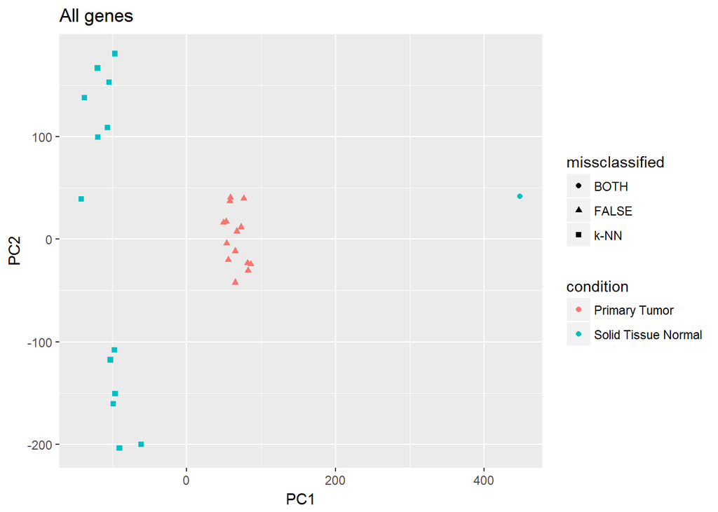

```r
# Collect the variable of interest for missclassification in a vector
missclassified <- as.factor(classification$missclassified)

# Plot the projection onto the first two components
points <- ggplot(data = as.data.frame(PCAgenes$x), aes(x = PC1, y = PC2, color = labeltest, shape = missclassified)) + geom_point() + scale_color_discrete(name = "condition") +
  ggtitle("All genes")
points
```

```r
######################TOP 250 GENES

# Principal components for the data with only 250 genes
PCAgeneslimited <- prcomp(testlimited)

# Extract the variance of the principal components
PCAgeneslimited$var <- PCAgeneslimited$sdev ^ 2

# Create a dataframe with the principal components and the variance scaled to a proportion
PCAgeneslimiteddf <- data.frame(as.factor(paste0("PC", seq(1 : 2))), (PCAgeneslimited$var[1 : 2] / sum(PCAgeneslimited$var)))
colnames(PCAgeneslimiteddf) <- c("PC", "value")
PCAgeneslimiteddf
```

```
##    PC      value
## 1 PC1 0.33279796
## 2 PC2 0.07021202
```

```r
# Create a dataframe with the knn classification, the svm classification, and the real values
classificationlimited <- data.frame(predictionknnlimited, predictionsvmlimited, labeltest)

# Transform factors to character to avoid discordance betwen different factor levels
classificationlimited[ , 1] <- as.character(classificationlimited[ , 1])
classificationlimited[ , 2] <- as.character(classificationlimited[ , 2])
classificationlimited[ , 3] <- as.character(classificationlimited[ , 3])

# Check if the labels are missclassified and classify accordingly
for (i in 1 : dim(classificationlimited)[1]) {
  if (classificationlimited[i, 1] == classificationlimited[i, 3] & classificationlimited[i, 2] == classificationlimited[i, 3]) {
    classificationlimited$missclassified[i] <- "FALSE"
  } else if (classificationlimited[i, 1] != classificationlimited[i, 3] & classificationlimited[i, 2] != classificationlimited[i, 3]) {
    classificationlimited$missclassified[i] <- "BOTH"
  } else if (classificationlimited[i, 1] != classificationlimited[i, 3] & classificationlimited[i, 2] == classificationlimited[i, 3]) {
    classificationlimited$missclassified[i] <- "k-NN"
  } else {
    classificationlimited$missclassified[i] <- "SVM"
  }
}
classificationlimited
```

```
##                  predictionknnlimited predictionsvmlimited
## TCGA_HC_8259_11A  Solid Tissue Normal  Solid Tissue Normal
## TCGA_EJ_7781_01A        Primary Tumor        Primary Tumor
## TCGA_G9_6348_01A        Primary Tumor        Primary Tumor
## TCGA_G9_6351_11A        Primary Tumor  Solid Tissue Normal
## TCGA_HC_8262_01A        Primary Tumor        Primary Tumor
## TCGA_J4_A83J_01A        Primary Tumor        Primary Tumor
## TCGA_G9_6362_01A        Primary Tumor        Primary Tumor
## TCGA_EJ_7327_11A        Primary Tumor  Solid Tissue Normal
## TCGA_EJ_7785_11A  Solid Tissue Normal  Solid Tissue Normal
## TCGA_G9_6499_11A        Primary Tumor  Solid Tissue Normal
## TCGA_G9_6365_01A        Primary Tumor        Primary Tumor
## TCGA_EJ_7784_01A        Primary Tumor        Primary Tumor
## TCGA_EJ_A8FO_01A        Primary Tumor        Primary Tumor
## TCGA_G9_6499_01A        Primary Tumor        Primary Tumor
## TCGA_CH_5767_11B        Primary Tumor        Primary Tumor
## TCGA_EJ_7317_01A        Primary Tumor        Primary Tumor
## TCGA_EJ_7783_11A  Solid Tissue Normal  Solid Tissue Normal
## TCGA_G9_6363_01A        Primary Tumor        Primary Tumor
## TCGA_EJ_7125_11A  Solid Tissue Normal  Solid Tissue Normal
## TCGA_G9_6496_11A  Solid Tissue Normal  Solid Tissue Normal
## TCGA_EJ_7781_11A  Solid Tissue Normal  Solid Tissue Normal
## TCGA_EJ_7786_01A        Primary Tumor        Primary Tumor
## TCGA_EJ_7317_11A        Primary Tumor  Solid Tissue Normal
## TCGA_EJ_7782_01A        Primary Tumor        Primary Tumor
## TCGA_EJ_7125_01A        Primary Tumor        Primary Tumor
## TCGA_EJ_7321_11A  Solid Tissue Normal  Solid Tissue Normal
## TCGA_EJ_7328_11A  Solid Tissue Normal  Solid Tissue Normal
## TCGA_EJ_7115_11A  Solid Tissue Normal  Solid Tissue Normal
##                            labeltest missclassified
## TCGA_HC_8259_11A Solid Tissue Normal          FALSE
## TCGA_EJ_7781_01A       Primary Tumor          FALSE
## TCGA_G9_6348_01A       Primary Tumor          FALSE
## TCGA_G9_6351_11A Solid Tissue Normal           k-NN
## TCGA_HC_8262_01A       Primary Tumor          FALSE
## TCGA_J4_A83J_01A       Primary Tumor          FALSE
## TCGA_G9_6362_01A       Primary Tumor          FALSE
## TCGA_EJ_7327_11A Solid Tissue Normal           k-NN
## TCGA_EJ_7785_11A Solid Tissue Normal          FALSE
## TCGA_G9_6499_11A Solid Tissue Normal           k-NN
## TCGA_G9_6365_01A       Primary Tumor          FALSE
## TCGA_EJ_7784_01A       Primary Tumor          FALSE
## TCGA_EJ_A8FO_01A       Primary Tumor          FALSE
## TCGA_G9_6499_01A       Primary Tumor          FALSE
## TCGA_CH_5767_11B Solid Tissue Normal           BOTH
## TCGA_EJ_7317_01A       Primary Tumor          FALSE
## TCGA_EJ_7783_11A Solid Tissue Normal          FALSE
## TCGA_G9_6363_01A       Primary Tumor          FALSE
## TCGA_EJ_7125_11A Solid Tissue Normal          FALSE
## TCGA_G9_6496_11A Solid Tissue Normal          FALSE
## TCGA_EJ_7781_11A Solid Tissue Normal          FALSE
## TCGA_EJ_7786_01A       Primary Tumor          FALSE
## TCGA_EJ_7317_11A Solid Tissue Normal           k-NN
## TCGA_EJ_7782_01A       Primary Tumor          FALSE
## TCGA_EJ_7125_01A       Primary Tumor          FALSE
## TCGA_EJ_7321_11A Solid Tissue Normal          FALSE
## TCGA_EJ_7328_11A Solid Tissue Normal          FALSE
## TCGA_EJ_7115_11A Solid Tissue Normal          FALSE
```

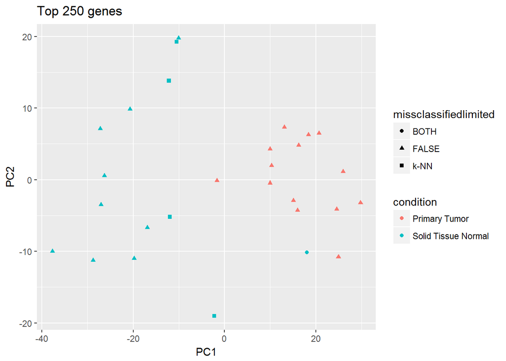

```r
# Collect the variable of interest for missclassification in a vector
missclassifiedlimited <- as.factor(classificationlimited$missclassified)

# Plot the projection onto the first two components
pointslimited <- ggplot(data = as.data.frame(PCAgeneslimited$x), aes(x = PC1, y = PC2, color = labeltest, shape = missclassifiedlimited)) + geom_point() + scale_color_discrete(name = "condition") +
  ggtitle("Top 250 genes")
pointslimited
```

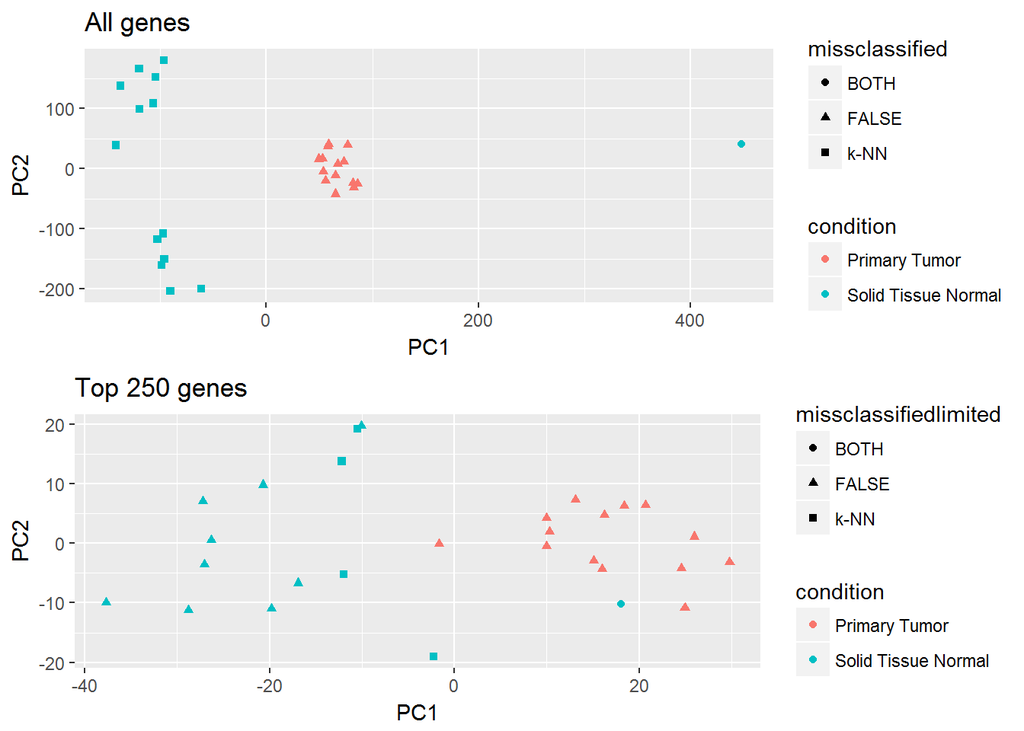

```r
## DISPLAY THE FIGURES NEXT TO EACH OTHER (I assume one up and one down, otherwise they appear too squeezed)
#install.packages("gridExtra")
library(gridExtra)
grid.arrange(points, pointslimited, ncol = 1)
```

2. Install the R devtools package and use it to install the package ggalluvial from Github: https: //github.com/corybrunson/ggalluvial. Use as reference the vignette, available at https://github.com/ corybrunson/ggalluvial/blob/master/vignettes/ggalluvial.rmd. In particular, look at the example provided for the “vaccination” data. Create two alluvial plots that compare the results in the test set from the two classifiers obtained from both the top 250 genes and the entire set of genes as shown in figure below. Set up the plots with the “True_Labels” column in the center as displayed in the figure. Arrange the plots as two panels of a single figure and name them properly.

```r
#install.packages("devtools")
library(devtools)

# Install ggalluvial following the instructions from the ggalluvial's author's website
#devtools::install_github("corybrunson/ggalluvial", build_vignettes = TRUE)
library(ggalluvial)

## ALL GENES

# Enter the data as above
method <- c(rep("k-NN", length(predictionknn)), rep("True_Labels", length(labeltest)), rep("SVM", length(predictionsvm)))
classification <- as.factor(c(as.character(predictionknn), as.character(labeltest), as.character(predictionsvm)))
subject <- rep(seq(from = 1, to = length(predictionknn)), 3)

# Collect the data in a dataframe
alluvialclassification <- data.frame(method, classification, subject)
alluvialclassification
```

```
##         method      classification subject
## 1         k-NN       Primary Tumor       1
## 2         k-NN       Primary Tumor       2
## 3         k-NN       Primary Tumor       3
## 4         k-NN       Primary Tumor       4
## 5         k-NN       Primary Tumor       5
## 6         k-NN       Primary Tumor       6
## 7         k-NN       Primary Tumor       7
## 8         k-NN       Primary Tumor       8
## 9         k-NN       Primary Tumor       9
## 10        k-NN       Primary Tumor      10
## 11        k-NN       Primary Tumor      11
## 12        k-NN       Primary Tumor      12
## 13        k-NN       Primary Tumor      13
## 14        k-NN       Primary Tumor      14
```

[output cut: 70 more lines]

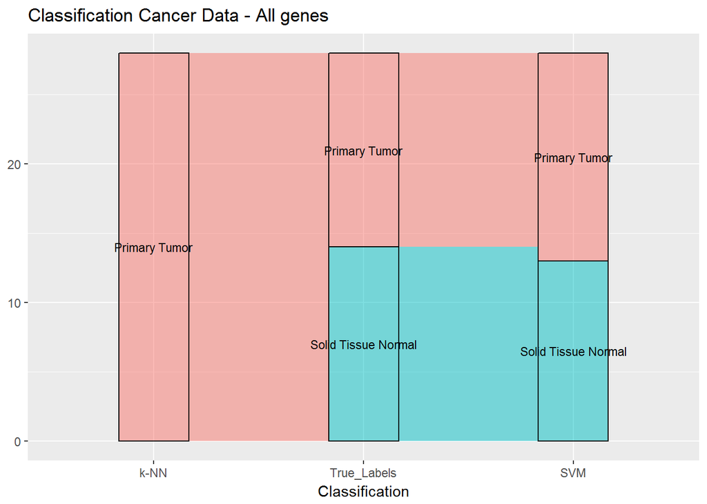

```r
# Order the levels of method for the plot
alluvialclassification$method <- ordered(alluvialclassification$method, levels = c("k-NN", "True_Labels", "SVM"))

# Create the plot
alluvialall <- ggplot(alluvialclassification,
       aes(x = method, stratum = classification, alluvium = subject, fill = classification, label = classification)) +
  geom_flow() +
  geom_stratum(alpha = 0.5) +
  geom_text(stat = "stratum", size = 3) +
  theme(legend.position = "none") +
  ggtitle("Classification Cancer Data - All genes") +
  xlab("Classification")
alluvialall
```

```r
## 250 GENES

# Enter the data as above
methodlimited <- c(rep("k-NN", length(predictionknnlimited)), rep("True_Labels", length(labeltest)), rep("SVM", length(predictionsvmlimited)))
classificationlimited <- as.factor(c(as.character(predictionknnlimited), as.character(labeltest), as.character(predictionsvmlimited)))
subjectlimited <- rep(seq(from = 1, to = length(predictionknnlimited)), 3)

# Collect the data in a dataframe
alluvialclassificationlimited <- data.frame(methodlimited, classificationlimited, subjectlimited)
alluvialclassificationlimited
```

```
##    methodlimited classificationlimited subjectlimited
## 1           k-NN   Solid Tissue Normal              1
## 2           k-NN         Primary Tumor              2
## 3           k-NN         Primary Tumor              3
## 4           k-NN         Primary Tumor              4
## 5           k-NN         Primary Tumor              5
## 6           k-NN         Primary Tumor              6
## 7           k-NN         Primary Tumor              7
## 8           k-NN         Primary Tumor              8
## 9           k-NN   Solid Tissue Normal              9
## 10          k-NN         Primary Tumor             10
## 11          k-NN         Primary Tumor             11
## 12          k-NN         Primary Tumor             12
## 13          k-NN         Primary Tumor             13
## 14          k-NN         Primary Tumor             14
```

[output cut: 70 more lines]

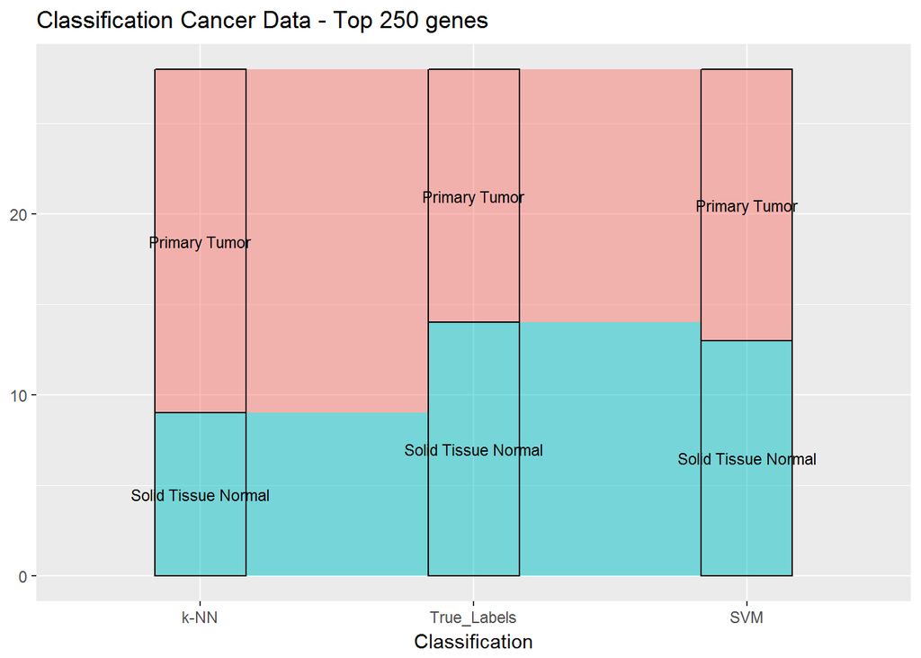

```r
# Order the levels of method for the plot
alluvialclassificationlimited$methodlimited <- ordered(alluvialclassificationlimited$methodlimited, levels = c("k-NN", "True_Labels", "SVM"))

# Create the plot
alluvial250 <- ggplot(alluvialclassificationlimited,
       aes(x = methodlimited, stratum = classificationlimited, alluvium = subjectlimited, fill = classificationlimited, label = classificationlimited)) +
  geom_flow() +
  geom_stratum(alpha = 0.5) +
  geom_text(stat = "stratum", size = 3) +
  theme(legend.position = "none") +
  ggtitle("Classification Cancer Data - Top 250 genes") +
  xlab("Classification")
alluvial250
```

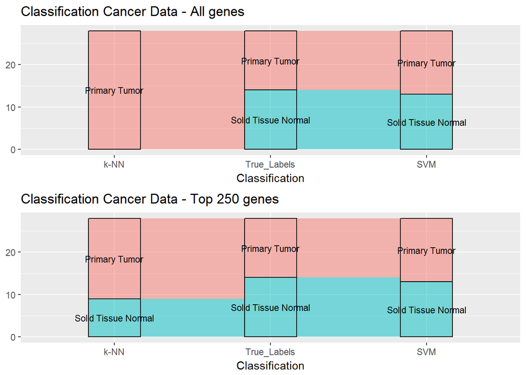

```r
## DISPLAY THE FIGURES NEXT TO EACH OTHER (I assume one up and one down, otherwise they appear too squeezed)
grid.arrange(alluvialall, alluvial250, ncol = 1)
```

## Problem 4

In this problem you will implement cross-validation for k-NN and determine the optimal number of neighbors and features to use for a k-NN classifier. 1. Write a function named knn_cv that performs k-fold cross-validation for a k-NN classifier. As input it should have: . the expression data D (already normalized) . labels L, already ordered according to the column names of the expression dataset . the number of folds K for the cross-validation . the k parameter for the K-NN classifier Note that in order to receive full credit, the function must be able to operate on datasets with variable numbers of samples, different from the data set that we provide for this problem set. The function must: . partition the data and iterate the k-NN classification K times using the samples of one of the K splits as test set at each iteration. Note that each sample must be used only once in the test set across all iterations. Also remember to generate K splits with a balanced number of samples per class. While not necessary, the function TRind created in Problem 1 above might be helpful. . in each iteration, perform the k-NN classification using the function knn3Train(). Use prob=FALSE. This way you repeat the classification K times on a training set that is different and has no overlaps with the training sets used in the other iterations. For reproducibility purposes, use a seed value of 10. . provide as output the average accuracy across the K iterations of the cross validation. Use the function confusionMatrix to extract the overall accuracy. Note that considering for example your data, with 7-fold cross-validation you should have 12 samples per test set at each iteration: 6 samples should be to Primary Tumor and 6 should be Solid Tissue Normal.

```r
## Function for cross validation
knn_cv <- function(D, L, K, k) {

  #INPUTS:
  # D (dataframe): expression data, already normalized and with samples in columns and genes in rows
  # L (vector): labels, already ordered according to the column names of the expression dataset
  # K (integer): number of folds for cross-validation
  # k (integer): parameter k for the knn

  #OUTPUT:
  # Average accuracy across the K iterations of the cross validation

  ## FUNCTION

  ###################### Partition the labels

  ## Transform the vector of labels L into a dataframe so that each row has an index
  originalLdf <- data.frame(L)
  originalLdf$index <- as.numeric(as.character(rownames(originalLdf)))



  ## For each loop of cross-validation the test set will be of size total database  divided K times and the rest of the database will be the train set

  # Dimensions of the dataframe length(L)
  # Number of subsets K
  # Dimensions of each subset length(L) / K
  sizefold <- round(length(L) / K)



  # DATA TO BE USED AS TEST SET (use data that has not been used yet, initially the same as the original, with each loop of the cross validation the data that has not been used yet for test set)
  Ldf <- originalLdf


  # Create an empty vector to collect the accuracies of each loop of the cross validation
  accuracyvector <- vector()
##################################################BEGINNING OF THE CROSS VALIDATION LOOP#########################

  for (i in 1 : K) {


  ## If the Ldf is smaller than the sizefold, it means that the last round of cross validation is smaller than the rest and we should use all data for test set

    ### BEGINNING OF THE IF LOOP
    # If the remaining dataframe is smaller than the sizefold
    if (dim(Ldf)[1] < sizefold) {

      # It is the last cross validation round and it is smaller than the rest, use it all
      classifiertest <- Ldf[ , "index"]

      # If not, partition as usual
    } else {


  ## As the database has 2 categories, and we want to ensure that the categories are similarly distributed in training and testing sets, we sample separately each category


  ## For category 1

  # Identify the indexes associated with category 1
  indexescategory1 <- Ldf[Ldf$L == levels(Ldf$L)[1], ][ , "index"]

  # Set the seed to 10 as specified in the problem
  set.seed(10)

  # Sample only from the first category and assign the elements belonging to the test set
  assignedtotestcategory1 <- sample(indexescategory1, sizefold / 2, replace = FALSE)


  ## For category 2

  # Identify the indexes associated with category 2
  indexescategory2 <- Ldf[Ldf$L == levels(Ldf$L)[2], ][ , "index"]

  # Set the seed to 10 as specified in the problem
  set.seed(10)

  # Sample only the second category and assign the elements belonging to the test set
  assignedtotestcategory2 <- sample(indexescategory2, sizefold / 2, replace = FALSE)


  # Create the output vector comprising the indexes of the test set
  classifiertest <- sort(c(assignedtotestcategory1, assignedtotestcategory2))

    }
  ### END OF THE IF LOOP

  # Output
  classifiertest


  ##############Eliminate rows that have been already used in prior test sets
  Ldf <- Ldf[- classifiertest , ]



  ###################### Partition the columns following the order included in the labels (I am assuming that the data is entered with the samples in the columns, not in the rows)

  # Create datatest (fold where the data will be tested in this round of cross validation)
  Dtest <- D[ , classifiertest]

  # Create datatrain (rest of the folds used for training in this round of cross validation)
  Dtrain <- D[ , - classifiertest]




  ###################### knn

  # Identify the real labels
  labeltrain <- L[- classifiertest]
  labeltest <- L[classifiertest]

  # Set the seed to 10 as specified in the problem
  set.seed(10)

  # Apply the knn
  predictionknn <- knn3Train(t(Dtrain), t(Dtest), cl = labeltrain, k = k, prob = FALSE)
predictionknn

  # Calculate the confusion matrix accuracy for this round of cross validation
  accuracy <- confusionMatrix(predictionknn, labeltest)$overall["Accuracy"]

  # Add this new accuracy to the vector
  accuracyvector <- c(accuracyvector, accuracy)
  ############################################################END OF THE CROSS VALIDATION LOOP#########################
  }

  # Calculate the mean of the accuracies across all rounds of cross validation
  meanaccuracy <- mean(accuracyvector)

  ## OUTPUT
  meanaccuracy

  # End of function
}
```

2. Use knn_cv to perform k-NN with 7-fold cross-validation for the following combinations of k parameters and top n number of features (using the order according to the p-values as before, remembering that the top p-values are the smallest ones): . k = c(2,5,7,9,11,13,15,17,19,21,25,30,40,50) . n = c(5,10,20,30,40,50,75,100,125,150,200,250) At the end you should create a 12x14 matrix of elements (n_j,k_i), each representing one combination of the k parameter and the number of features n from the values of the two grids provided above. Each element of the matrix should report the average accuracy resulting from the cross-validation. Note that if you are not able to solve the first part of this problem, use the functions trainControl and train from caret package as explained in the lecture. Do not use repeats and keep the default grid of k parameters provided by the train function, without setting the grid as above. Do not preprocess the data, as we have already normalized them in Problem 1 above. For the purpose of this exercise, which is only to find the best combination(s) of parameters and number of features and not to 5 predict new samples, provide as input the entire dataset: the function train will split the data automatically. Use the accuracies for k reported by the function to generate the matrix at different number of features.

```r
# Look at the differential expression dataframe
genediff[1 : 10, 1 : 5]
```

```
##            baseMean log2FoldChange      lfcSE        stat       pvalue
## TSPAN6   4566.80873   -0.005656142 0.09671310 -0.05848372 9.533633e-01
## TNMD       26.29104   -1.374897819 0.32652756 -4.21066394 2.546213e-05
## DPM1     1586.60727   -0.187201681 0.06278721 -2.98152594 2.868157e-03
## SCYL3    1332.80629    0.164029587 0.07327866  2.23843582 2.519265e-02
## C1orf112  252.42867   -0.023198092 0.07798493 -0.29746891 7.661085e-01
## FGR       324.97614   -0.307400293 0.14424650 -2.13107628 3.308286e-02
## CFH      2025.06551   -1.065083117 0.18423406 -5.78114130 7.419554e-09
## FUCA2    3674.63067    0.556293570 0.08560514  6.49836618 8.119698e-11
## GCLC     3652.73876   -0.262641067 0.08930875 -2.94082121 3.273434e-03
## NFYA     2113.81499    0.242489570 0.07070881  3.42941112 6.048925e-04
```

```r
# Order the new dataframe by p values and check that it looks reasonable
genediffpvalues <- genediff[order(genediff$pvalue), ]
genediffpvalues[1 : 10, 1 : 5]
```

```
##              baseMean log2FoldChange      lfcSE      stat       pvalue
## SLIT1      711.050551       2.809551 0.23580783  11.91458 9.936563e-33
## EPHA10     400.861359       1.820425 0.15449701  11.78292 4.781032e-32
## CTF1       684.683513      -1.505533 0.12836350 -11.72867 9.087346e-32
## LINC01475    8.463937       4.431921 0.38058650  11.64498 2.433884e-31
## TRIP6     2971.303615      -1.299372 0.11209227 -11.59198 4.525289e-31
## GSTP1     9450.052488      -1.722404 0.14987494 -11.49228 1.442567e-30
## GATM       979.026988      -1.543147 0.13544747 -11.39295 4.533578e-30
## DOK4      1412.169428      -1.126587 0.09969596 -11.30023 1.308800e-29
## AMACR     5145.778450       2.753618 0.24495553  11.24130 2.556004e-29
## BEND5      260.643840      -1.320554 0.11857051 -11.13728 8.259938e-29
```

```r
## CREATE THE MATRIX

# Create an empty 12x14 matrix
results <- matrix( , nrow = 12, ncol = 14)
results
```

```
##       [,1] [,2] [,3] [,4] [,5] [,6] [,7] [,8] [,9] [,10] [,11] [,12] [,13]
##  [1,]   NA   NA   NA   NA   NA   NA   NA   NA   NA    NA    NA    NA    NA
##  [2,]   NA   NA   NA   NA   NA   NA   NA   NA   NA    NA    NA    NA    NA
##  [3,]   NA   NA   NA   NA   NA   NA   NA   NA   NA    NA    NA    NA    NA
##  [4,]   NA   NA   NA   NA   NA   NA   NA   NA   NA    NA    NA    NA    NA
##  [5,]   NA   NA   NA   NA   NA   NA   NA   NA   NA    NA    NA    NA    NA
##  [6,]   NA   NA   NA   NA   NA   NA   NA   NA   NA    NA    NA    NA    NA
##  [7,]   NA   NA   NA   NA   NA   NA   NA   NA   NA    NA    NA    NA    NA
##  [8,]   NA   NA   NA   NA   NA   NA   NA   NA   NA    NA    NA    NA    NA
##  [9,]   NA   NA   NA   NA   NA   NA   NA   NA   NA    NA    NA    NA    NA
## [10,]   NA   NA   NA   NA   NA   NA   NA   NA   NA    NA    NA    NA    NA
## [11,]   NA   NA   NA   NA   NA   NA   NA   NA   NA    NA    NA    NA    NA
## [12,]   NA   NA   NA   NA   NA   NA   NA   NA   NA    NA    NA    NA    NA
##       [,14]
##  [1,]    NA
##  [2,]    NA
##  [3,]    NA
##  [4,]    NA
##  [5,]    NA
##  [6,]    NA
##  [7,]    NA
##  [8,]    NA
##  [9,]    NA
## [10,]    NA
## [11,]    NA
## [12,]    NA
```

```r
# Insert the data as provided in the problem
kvalues <- c(2,5,7,9,11,13,15,17,19,21,25,30,40,50)
nvalues <- c(5,10,20,30,40,50,75,100,125,150,200,250)

## Create the loop to apply that information in the 14 different conditions
for (j in 1 : length(nvalues)) {

  # Define n for this case
  n <- nvalues[j]

  # Identify the top n genes
  genediffpvaluestopn <- genediffpvalues[1 : n, ]

  # Create the data with the n top genes
  D <- genedata[rownames(genediffpvaluestopn), ]

  for (i in 1 : length(kvalues)) {

  # Define k for this case
  k <- kvalues[i]

  # Apply the function
  accuracyforthiscondition <- knn_cv(D = D, L = orderedvectorofsamples, K = 7, k = k)

  # Add the value to the matrix
  results[j, i] <- accuracyforthiscondition
    }
}

## RETURN THE MATRIX OF RESULTS
results
```

```
##            [,1]      [,2]      [,3]      [,4]      [,5]      [,6]
##  [1,] 0.7142857 0.8214286 0.7738095 0.8214286 0.8571429 0.8452381
##  [2,] 0.7738095 0.8095238 0.8095238 0.8333333 0.8452381 0.8452381
##  [3,] 0.7857143 0.8452381 0.8095238 0.8452381 0.8809524 0.9047619
##  [4,] 0.8571429 0.8809524 0.9047619 0.9166667 0.8571429 0.8809524
##  [5,] 0.8452381 0.8571429 0.8809524 0.8809524 0.8809524 0.8809524
##  [6,] 0.8095238 0.8809524 0.8809524 0.8809524 0.8809524 0.8690476
##  [7,] 0.8452381 0.8690476 0.8809524 0.8809524 0.8809524 0.8809524
##  [8,] 0.8809524 0.8809524 0.8809524 0.8809524 0.8809524 0.8809524
##  [9,] 0.8690476 0.8928571 0.8571429 0.8571429 0.8571429 0.8571429
## [10,] 0.8333333 0.8690476 0.8571429 0.8571429 0.8571429 0.8571429
## [11,] 0.8333333 0.8690476 0.8690476 0.8809524 0.8928571 0.8928571
## [12,] 0.7976190 0.8571429 0.8690476 0.8571429 0.8571429 0.8571429
##            [,7]      [,8]      [,9]     [,10]     [,11]     [,12]
##  [1,] 0.8333333 0.8333333 0.8333333 0.8809524 0.8571429 0.8214286
```

[output cut: 24 more lines]

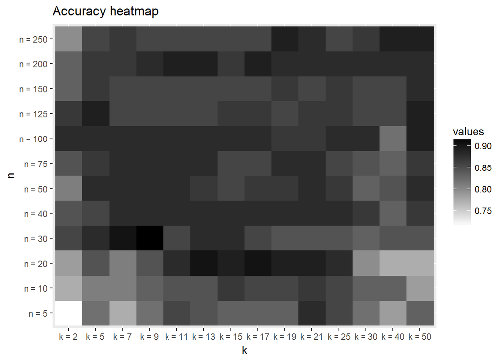

```r
## Create empty dataframe
resultsdf <- data.frame()

# Create an empty vector to save values
values <- vector()

## Create loop to enter the data
for (i in 1 : 14) {
  for (j in 1 : 12) {
    # Append the new value
    values <- c(values, results[j, i])
  }
}

# Create the dataframe entering the values
resultsdf <- expand.grid(
rows = paste0("n = ", nvalues),
columns = paste0("k = ", kvalues))
resultsdf$accuracy <- values
Accuracy <- resultsdf$accuracy

#install.packages("ggplot2")
library(ggplot2)

# Create the plot
heatmapbest <- ggplot(resultsdf) + geom_tile(aes(x = columns, y = rows, fill = values)) +
  scale_fill_gradientn(colours = c("gray100","gray0")) +
  ggtitle("Accuracy heatmap") + xlab("k") + ylab("n")
heatmapbest
```

```r
## ANSWER 3.3
# The best combinations are
# n = 30 and k = 9
# Followed closely by
# n = 30 and k = 7
# n = 20 and k = 17
```

4. Bonus Points: Using the same data as in the heatmap, create a line chart matrix like the one shown below.

```r
#install.packages("tidyverse")
library(tidyverse)
# Create a tibble (I am sure there are more elegant and less painful ways of creating this tibble, but I do not remember them if they were explained)
resultstb <- tribble(
  ~n, ~k2, ~k5, ~k7, ~k9, ~k11, ~k13, ~k15, ~k17, ~k19, ~k21, ~k25, ~k30, ~k40, ~k50,
  "n5", results[1, 1], results[1, 2], results[1, 3], results[1, 4], results[1, 5], results[1, 6], results[1, 7], results[1, 8], results[1, 9], results[1, 10], results[1, 11], results[1, 12], results[1, 13], results[1, 14],
  "n10", results[2, 1], results[2, 2], results[2, 3], results[2, 4], results[2, 5], results[2, 6], results[2, 7], results[2, 8], results[2, 9], results[2, 10], results[2, 11], results[2, 12], results[2, 13], results[2, 14],
  "n20", results[3, 1], results[3, 2], results[3, 3], results[3, 4], results[3, 5], results[3, 6], results[3, 7], results[3, 8], results[3, 9], results[3, 10], results[3, 11], results[3, 12], results[3, 13], results[3, 14],
  "n30", results[4, 1], results[4, 2], results[4, 3], results[4, 4], results[4, 5], results[4, 6], results[4, 7], results[4, 8], results[4, 9], results[4, 10], results[4, 11], results[4, 12], results[4, 13], results[4, 14],
  "n40", results[5, 1], results[5, 2], results[5, 3], results[5, 4], results[5, 5], results[5, 6], results[5, 7], results[5, 8], results[5, 9], results[5, 10], results[5, 11], results[5, 12], results[5, 13], results[5, 14],
  "n50", results[6, 1], results[6, 2], results[6, 3], results[6, 4], results[6, 5], results[6, 6], results[6, 7], results[6, 8], results[6, 9], results[6, 10], results[6, 11], results[6, 12], results[6, 13], results[6, 14],
  "n75", results[7, 1], results[7, 2], results[7, 3], results[7, 4], results[7, 5], results[7, 6], results[7, 7], results[7, 8], results[7, 9], results[7, 10], results[7, 11], results[7, 12], results[7, 13], results[7, 14],
  "n100", results[8, 1], results[8, 2], results[8, 3], results[8, 4], results[8, 5], results[8, 6], results[8, 7], results[8, 8], results[8, 9], results[8, 10], results[8, 11], results[8, 12], results[8, 13], results[8, 14],
  "n125", results[9, 1], results[9, 2], results[9, 3], results[9, 4], results[9, 5], results[9, 6], results[9, 7], results[9, 8], results[9, 9], results[9, 10], results[9, 11], results[9, 12], results[9, 13], results[9, 14],
  "n150", results[10, 1], results[10, 2], results[10, 3], results[10, 4], results[10, 5], results[10, 6], results[10, 7], results[10, 8], results[10, 9], results[10, 10], results[10, 11], results[10, 12], results[10, 13], results[10, 14],
  "n200", results[11, 1], results[11, 2], results[11, 3], results[11, 4], results[11, 5], results[11, 6], results[11, 7], results[11, 8], results[11, 9], results[11, 10], results[11, 11], results[11, 12], results[11, 13], results[11, 14],
  "n250", results[12, 1], results[12, 2], results[12, 3], results[12, 4], results[12, 5], results[12, 6], results[12, 7], results[12, 8], results[12, 9], results[12, 10], results[12, 11], results[12, 12], results[12, 13], results[12, 14]
)

# Tidy the tibble
resultstb <- resultstb %>% gather(`k2`, `k5`, `k7`, `k9`, `k11`, `k13`, `k15`, `k17`, `k19`, `k21`, `k25`, `k30`, `k40`, `k50`, key = "k", value = "accuracy")
resultstb
```

```
## # A tibble: 168 x 3
##        n     k  accuracy
##    <chr> <chr>     <dbl>
##  1    n5    k2 0.7142857
##  2   n10    k2 0.7738095
##  3   n20    k2 0.7857143
##  4   n30    k2 0.8571429
##  5   n40    k2 0.8452381
##  6   n50    k2 0.8095238
##  7   n75    k2 0.8452381
##  8  n100    k2 0.8809524
##  9  n125    k2 0.8690476
## 10  n150    k2 0.8333333
## # ... with 158 more rows
```

[figure not shown]

```r
# Create the plot
lineplot <- ggplot(data = resultstb) + geom_line(mapping = aes(x = k, y = resultstb$accuracy, group = n)) + facet_wrap(~n, ncol = 4, nrow = 3) +
  ggtitle("Line plot") +
  ylab("Accuracy")
lineplot
```

## Problem 5

22 hours